# Talk Results Companion V2: RWE MIB Symposium Slides

## 8.2 Choosing an intervention type

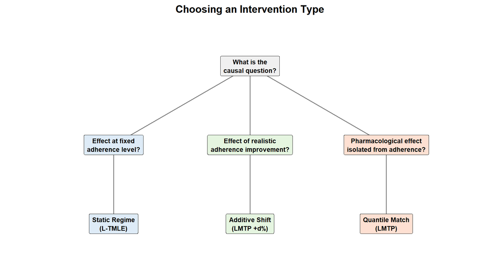

Figure 6: Choosing the right intervention type based on the causal question.

# 9 Slide 11: Estimation — Longitudinal TMLE

**REPLACES:** “Visual estimation figure” and “Pipeline diagram: data -> estimand -> counterfactual contrast -> estimate”

## 9.1 How L-TMLE works

Longitudinal TMLE estimates counterfactual outcomes under hypothetical treatment regimes (e.g., “what if PDC were held at ‘high’ for all 4 blocks?”) while properly adjusting for time-varying confounders that are themselves affected by prior treatment. It proceeds in three stages:

1. **Define the node structure and intervention.** At each block $k$, the observed data follow the ordering $L_k \to A_k \to Y_k$, where $L_k$ is the time-varying confounder (health status), $A_k$ is adherence (categorised PDC), and $Y_k$ is the outcome (virologic failure, absorbing). The intervention $\bar{a}$ specifies the adherence category at every block (e.g., always “high”).
2. **Fit two nuisance models at each block:**
   - **Q-model** (outcome regression): $E[Y_k \mid L_k, A_k, \text{past}]$ — predicts failure risk given current confounder, treatment, and history.
   - **g-model** (propensity / treatment mechanism): $P(A_k \mid L_k, \text{past})$ — predicts the probability of the observed adherence category given covariates.
3. **Backward iterative targeting.** Starting from the *last* time point ($k = K$) and working backward to $k = 1$:
   - Compute the initial outcome prediction $\hat{Q}_k$ under the intervention $\bar{a}$.
   - Update $\hat{Q}_k$ using the “clever covariate” derived from $\hat{g}_k$, solving a logistic regression submodel that debiases the plug-in estimate.
   - Pass the updated $\hat{Q}_k^*$ backward as the pseudo-outcome for the next block’s Q-model.
   - At $k = 1$, the sample average of $\hat{Q}_1^*$ is the L-TMLE estimate of $E[Y(\bar{a})]$.

This backward recursion is **not** the same as standard sequential regression: the TMLE targeting step makes the estimator **double-robust** — consistent if *either* the Q-model or the g-model is correctly specified, and locally efficient when both are correct. Standard errors come from the efficient influence curve.

## 9.2 Backward iteration diagram

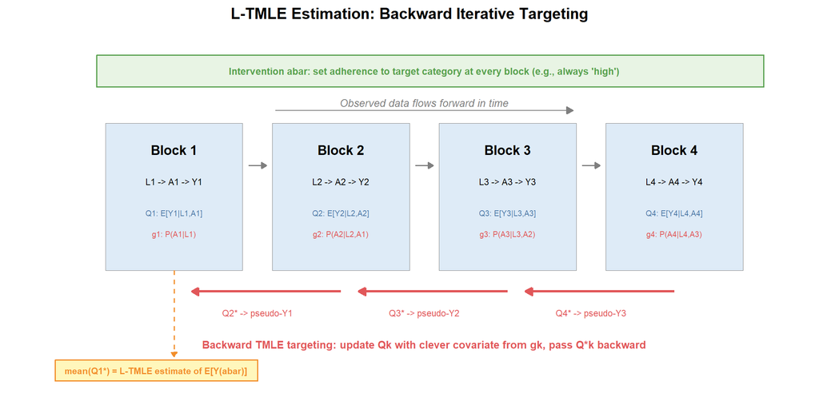

Figure 7: L-TMLE backward iteration: starting from Block 4, each updated Q* becomes the pseudo-outcome for the previous block.

## 9.3 Step-by-step: how L-TMLE untangles the confounding

Suppose we want to answer: “What would the 12-month failure risk be if every patient maintained high adherence at every quarter?” Here is what L-TMLE does, in plain English.

**Step 1 — Learn the treatment mechanism (the “g-model”).** At each quarter, we build a model that predicts: given a patient’s current health status and history, how likely were they to actually have high adherence? This captures the real-world patterns — for example, sicker patients are less likely to be highly adherent. We need this model because it tells us *how unusual* it would be for a given patient to follow the hypothetical regime we’re interested in.

**Step 2 — Learn the outcome risk (the “Q-model”).** At each quarter, we build a second model that predicts: given a patient’s health status, adherence level, and history, what is their probability of virologic failure? This is the standard kind of prediction model clinicians are used to — but we fit one at every time point, not just at baseline.

**Step 3 — Start at the last quarter and work backward.** This is the key step that handles time-dependent confounding. We start at Quarter 4 (the end of follow-up):

- *Quarter 4:* Using the Q-model, predict each patient’s failure risk *as if* they had high adherence in Q4, regardless of what they actually did. Then adjust this prediction using the g-model — patients who were unlikely to have high adherence naturally get upweighted, because they provide more information about what happens under the hypothetical regime. This adjustment is the “targeting” step, and it removes the bias that would come from simply plugging in the intervention.
- *Quarter 3:* Now take the adjusted Q4 predictions and treat them as the “outcome” for Q3. Fit the Q-model again, this time predicting the Q4-adjusted risk as a function of Q3 health, adherence, and history. Again plug in “high adherence” for Q3 and apply the targeting adjustment using the Q3 g-model. This propagates the causal effect backward through time.
- *Quarters 2 and 1:* Repeat the same process. Each step peels back one layer of time-dependent confounding. By the time we reach Q1, we have a predicted failure risk for each patient under the hypothetical regime of sustained high adherence across all four quarters — properly adjusted for the fact that health affects adherence, adherence affects health, and both affect outcomes.

**Step 4 — Average over the population.** The final L-TMLE estimate is simply the average of the Q1 adjusted predictions across all patients. This is the estimated counterfactual risk: “if everyone had been highly adherent for 12 months, this is how many would have experienced virologic failure.”

**Why this works when standard regression doesn’t:** Standard regression tries to estimate the effect of adherence by *conditioning* on it — essentially comparing patients who happened to be highly adherent to those who weren’t. But patients with high adherence are systematically healthier (because health drives adherence), so this comparison is confounded. L-TMLE avoids this by never conditioning on adherence. Instead, it *intervenes* on adherence (setting it to the target level) and uses the g-model to reweight the analysis so that the comparison is fair. The backward iteration ensures that this reweighting accounts for the full chain of feedback between health and adherence across all time points.

## 9.4 Node structure in this simulation

The table below shows how the V4 simulation maps onto the L-TMLE node structure. Adherence is categorised into three levels (low / mid / high) and dummy-coded as two binary treatment nodes per block; the `ltmle` package then sets these to the intervention value $\bar{a}$ rather than conditioning on them.

Table 3: L-TMLE node structure per block. Baseline W0 and A0 (drug) enter as fixed covariates.

| Block | Role | Variable | Description | L-TMLE action |
| --- | --- | --- | --- | --- |
| k = 1 | Confounder (L) | L_1 | Time-varying health status (continuous) | Adjust for (in Q and g models) |
| k = 1 | Treatment (A) | Acat2_1 | 1{PDC category = mid} | SET to intervention value (abar) |
| k = 1 | Treatment (A) | Acat3_1 | 1{PDC category = high} (reference = low) | SET to intervention value (abar) |
| k = 1 | Outcome (Y) | Y_1 | Virologic failure (absorbing binary) | Predict (target of estimation) |
| k = 2 | Confounder (L) | L_2 | Time-varying health status (continuous) | Adjust for (in Q and g models) |
| k = 2 | Treatment (A) | Acat2_2 | 1{PDC category = mid} | SET to intervention value (abar) |
| k = 2 | Treatment (A) | Acat3_2 | 1{PDC category = high} (reference = low) | SET to intervention value (abar) |
| k = 2 | Outcome (Y) | Y_2 | Virologic failure (absorbing binary) | Predict (target of estimation) |
| k = 3 | Confounder (L) | L_3 | Time-varying health status (continuous) | Adjust for (in Q and g models) |
| k = 3 | Treatment (A) | Acat2_3 | 1{PDC category = mid} | SET to intervention value (abar) |
| k = 3 | Treatment (A) | Acat3_3 | 1{PDC category = high} (reference = low) | SET to intervention value (abar) |
| k = 3 | Outcome (Y) | Y_3 | Virologic failure (absorbing binary) | Predict (target of estimation) |
| k = 4 | Confounder (L) | L_4 | Time-varying health status (continuous) | Adjust for (in Q and g models) |
| k = 4 | Treatment (A) | Acat2_4 | 1{PDC category = mid} | SET to intervention value (abar) |
| k = 4 | Treatment (A) | Acat3_4 | 1{PDC category = high} (reference = low) | SET to intervention value (abar) |
| k = 4 | Outcome (Y) | Y_4 | Virologic failure (absorbing binary) | Predict (target of estimation) |

## 9.5 Why this matters: double robustness

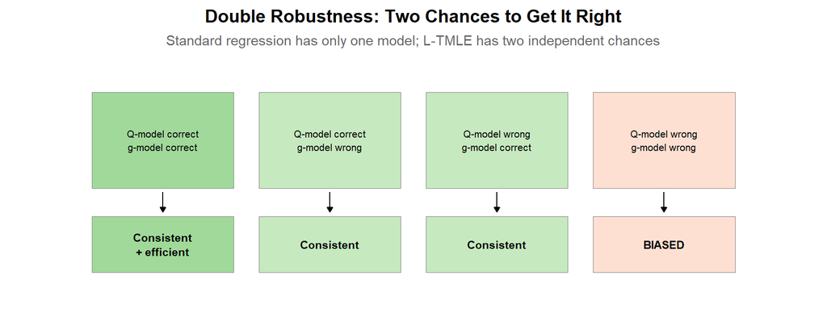

Figure 8: Double-robustness property of L-TMLE. The estimator is consistent if either the outcome model (Q) or the treatment model (g) is correctly specified.

### 9.5.1 Key properties of L-TMLE in this setting

- **Intervenes rather than conditions.** Standard regression conditions on adherence as a covariate (inducing collider bias when adherence is affected by prior health). L-TMLE *replaces* the observed adherence with the intervention value $\bar{a}$, then estimates what would have happened.
- **Handles the feedback loop.** At each block, the g-model learns the treatment mechanism $P(A_k \mid L_k, \text{past})$ and the Q-model learns the outcome risk $E[Y_k \mid L_k, A_k, \text{past}]$. The targeting step reweights the Q-model using the g-model to remove confounding bias, even though $L_k$ is affected by prior adherence.
- **Backward recursion is essential.** Because the outcome is cumulative (survival over $K$ blocks), L-TMLE must propagate information backward: the updated prediction $\hat{Q}_k^*$ at block $k$ becomes the pseudo-outcome for block $k-1$. This iterative conditional expectation (ICE) approach correctly accounts for the sequential structure.
- **Influence-curve inference.** Standard errors and 95% CIs are derived from the efficient influence curve, not from bootstrap or sandwich estimators. This provides valid inference under the semiparametric model even when Super Learner is used for the nuisance models.

[output not shown]

[output cut: 112 more lines]

[output not shown]

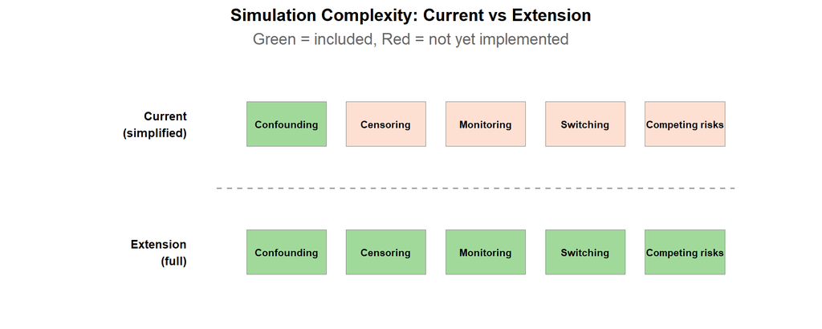

Figure 9: Version 3: Before/after — simplified simulation vs full complexity.

# 10 Slide 17: Extensions 2-3 — Mediation & Adherence History

**REPLACES:** `Picture45.jpg`, `Picture2.jpg` — mediation analysis and timing of poor adherence.

These extensions have not yet been implemented. Below are 3 schematic proposals.

## 10.1 Version 1: Mediation DAG (treatment -> adherence -> outcome)

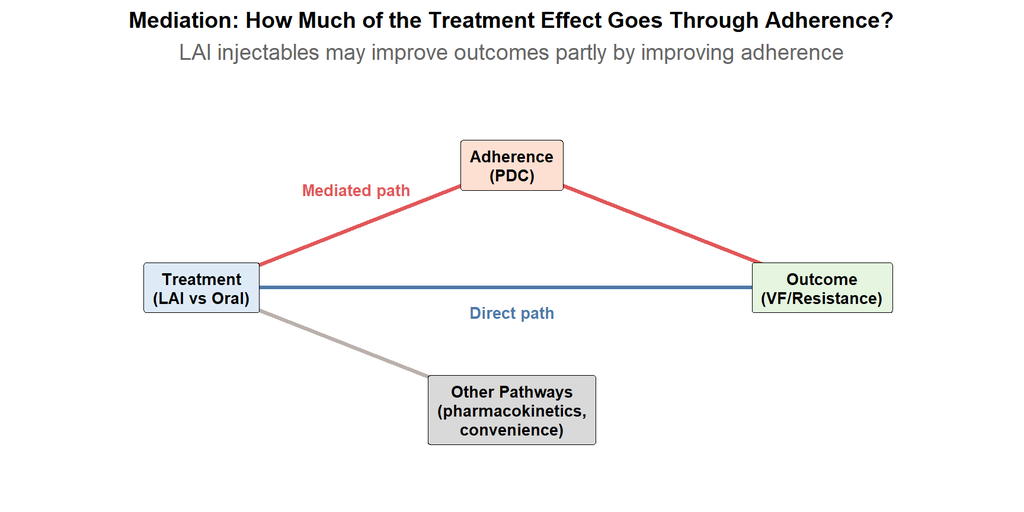

Figure 10: Version 1: Mediation DAG — decomposing the total effect of treatment into direct, mediated (through adherence), and other pathways.

## 10.2 Version 2: Adherence trajectory patterns

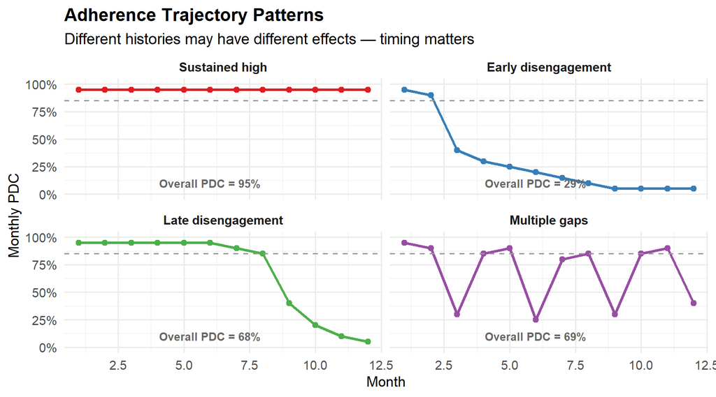

## 10.3 Version 3: Effect decomposition bar chart (conceptual)

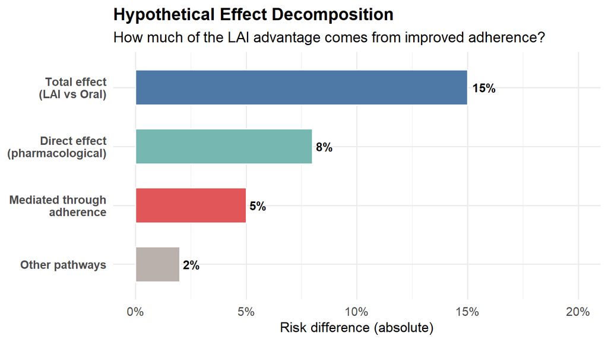

Figure 12: Version 3: Conceptual decomposition of treatment effect into direct and adherence-mediated components.

# 11 Slide 18: Takeaway

# 12 Slide 19: Next Steps

No figure/table placeholder — text-only slide.

# 13 Appendix: Bias Comparison — Naive vs L-TMLE

[figure not shown]

| Drug | Stratum | Method | Mean Bias | SE(mean) | Iterations |
| --- | --- | --- | --- | --- | --- |
| Drug A | Low | Naive | -2.1 pp | 0.3 pp | 30 |
| Drug A | Low | L-TMLE | -3.9 pp | 0.4 pp | 30 |
| Drug A | Mid | Naive | -0.7 pp | 0.2 pp | 30 |
| Drug A | Mid | L-TMLE | +0.4 pp | 0.5 pp | 30 |
| Drug A | High | Naive | -3.2 pp | 0.3 pp | 30 |
| Drug A | High | L-TMLE | -1.1 pp | 0.6 pp | 30 |
| Drug B | Low | Naive | -9.1 pp | 0.5 pp | 30 |
| Drug B | Low | L-TMLE | -13.3 pp | 0.7 pp | 30 |
| Drug B | Mid | Naive | -0.2 pp | 0.3 pp | 30 |
| Drug B | Mid | L-TMLE | -0.2 pp | 0.4 pp | 30 |
| Drug B | High | Naive | -1.4 pp | 0.2 pp | 30 |
| Drug B | High | L-TMLE | +1.3 pp | 0.5 pp | 30 |

# 14 Export: saved ggplot objects

```
Saved 9 figure(s) to C:/Users/andre/OneDrive/Documents/hiv_adherence_simulation/simulation V4/manuscript/talk_v2_figures.rds
```

```
Available figures:
```

```
 - fig-bias-all
 - fig-slide11-backward
 - fig-slide16-dag
 - fig-slide17-v1
 - fig-slide17-v3
 - fig-slide6-dag
 - fig-slide7-v2
 - fig-slide8-schematic-v1
 - fig-slide8-schematic-v2
```